# Model Selection

## Overview

- Subset Selection - identify a subset of $p$ predictors that we believe to be related to the response. Fit a model using least squares on reduced set of varibales.
- Regularization - fit a model with all $p$ predicators except that the estimated coefficients are shrunken towards zero relative to the least squares estimates. This shrinkage (regularization) reduces variance. Depending on the shrinkage, some coefficients may be estimated to be exactly zero.
- Dimension Reduction - project $p$ predictors into a $M$-dimensional subspace, $M < p$. $M$ different linear combinations, or projections of the variables are computed and used as predictors to fit a linear regression model.

### Linear Model Selection and Regularization

A linear model has distinct advantages in terms of inference and, on real-world problems, is often surprisingly competitive in relation to non-linear methods. Hence, before moving to the non-linear world, we discuss some ways in which the simple linear model can be improved, by replacing plain least squares fitting with some alternative fitting procedures. This in turn yields better prediction accuracy and model interpretability.

### Prediction Accuracy

When $n$ is not much larger than $p$,there can be a lot of variability in the least squares fit, resulting in overfitting and consequently poor predictions on future observations not used in model training. And if $p > n$, then there is no longer a unique least squares coefficient estimate: the variance is infinite so the method cannot be used at all. By constraining or shrinking the estimated coefficients, we can often substantially reduce the variance at the cost of a negligible increase in bias. This can lead to substantial improvements in the accuracy with which we can predict the response for observations not used in model training.

### Model Interpretability

It is often the case that some or many of the variables used in a multiple regression model are in fact not associated with the response. Including such irrelevant variables leads to unnecessary complexity in the resulting model. By removing these variables—that is, by setting the corresponding coefficient estimates to zero—we can obtain a model that is more easily interpreted. Least squares is extremely unlikely to yield any coefficient estimates that are exactly zero. We will see some approaches for automatically performing feature selection or variable selection—that is, for excluding irrelevant variables from a multiple regression model.

### Data

We will use the Hitters dataset for this recitation, which has 322 observations with the following 20 variables pertaining to baseball:

- AtBat Number of times at bat in 1986
- Hits Number of hits in 1986
- HmRun Number of home runs in 1986
- Runs Number of runs in 1986
- RBI Number of runs batted in in 1986
- Walks Number of walks in 1986
- Years Number of years in the major leagues
- CAtBat Number of times at bat during his career
- CHits Number of hits during his career
- CHmRun Number of home runs during his career
- CRuns Number of runs during his career
- CRBI Number of runs batted in during his career
- CWalks Number of walks during his career
- League A factor with levels A and N indicating player’s league at the end of 1986
- Division A factor with levels E and W indicating player’s division at the end of 1986
- PutOuts Number of put outs in 1986
- Assists Number of assists in 1986
- Errors Number of errors in 1986
- Salary 1987 annual salary on opening day in thousands of dollars
- NewLeague A factor with levels A and N indicating player’s league at the beginning of 1987

We wish to find a model that explains and predicts a baseball players' salary.

## Subset Selection

```python
#Data Wrangling
import pandas as pd
import numpy as np

#Preprocessing
from sklearn.model_selection import train_test_split
from sklearn.preprocessing import scale

#Plotting
import matplotlib.pyplot as plt
import seaborn as sns

#Metrics
import itertools
import time
from sklearn.metrics import mean_squared_error

#Models
import statsmodels.api as sm
from sklearn.linear_model import Ridge, RidgeCV, Lasso, LassoCV
```

```python
df = pd.read_csv('Hitters.csv')
df.head()
```

|  | Name | AtBat | Hits | HmRun | Runs | RBI | Walks | Years | CAtBat | CHits | ... | CRuns | CRBI | CWalks | League | Division | PutOuts | Assists | Errors | Salary | NewLeague |
| --- | --- | --- | --- | --- | --- | --- | --- | --- | --- | --- | --- | --- | --- | --- | --- | --- | --- | --- | --- | --- | --- |
| 0 | -Andy Allanson | 293 | 66 | 1 | 30 | 29 | 14 | 1 | 293 | 66 | ... | 30 | 29 | 14 | A | E | 446 | 33 | 20 | NaN | A |
| 1 | -Alan Ashby | 315 | 81 | 7 | 24 | 38 | 39 | 14 | 3449 | 835 | ... | 321 | 414 | 375 | N | W | 632 | 43 | 10 | 475.0 | N |
| 2 | -Alvin Davis | 479 | 130 | 18 | 66 | 72 | 76 | 3 | 1624 | 457 | ... | 224 | 266 | 263 | A | W | 880 | 82 | 14 | 480.0 | A |
| 3 | -Andre Dawson | 496 | 141 | 20 | 65 | 78 | 37 | 11 | 5628 | 1575 | ... | 828 | 838 | 354 | N | E | 200 | 11 | 3 | 500.0 | N |
| 4 | -Andres Galarraga | 321 | 87 | 10 | 39 | 42 | 30 | 2 | 396 | 101 | ... | 48 | 46 | 33 | N | E | 805 | 40 | 4 | 91.5 | N |

5 rows × 21 columns

```python
# observe number of missing values
print (df['Salary'].isnull().sum())
```

```
59
```

```python
# Drop rows with missing values along with player names
df = df.dropna().drop('Name', axis=1)
# rows with missing values have been removed
print (df['Salary'].isnull().sum())
```

```
0
```

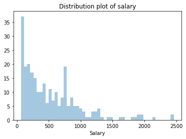

```python
sns.distplot(df['Salary'],kde=False,bins = 50)
plt.title("Distribution plot of salary")
plt.show()
```

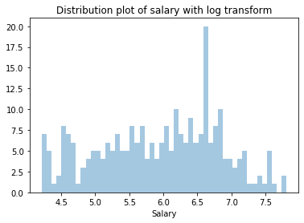

```python
#Perform log transform on salary to minimize the effects of skewness
df['Salary'] = np.log(df['Salary'])
sns.distplot(df['Salary'],kde=False,bins = 50)
plt.title("Distribution plot of salary with log transform")
plt.show()
```

```python
# get_dummies convert categorical variables into indicator variables.
dummies = pd.get_dummies(df[['League', 'Division', 'NewLeague']]) #One Hot encding
y = df.Salary

# Drop the column with independent variables and categorical variables
X_ = df.drop(['Salary', 'League', 'Division', 'NewLeague'], axis=1).astype('float64')
X = pd.concat([X_, dummies[['League_N', 'Division_W', 'NewLeague_N']]], axis=1)
```

```python
X_train, X_test, y_train, y_test = train_test_split(X, y, test_size=0.2, random_state=1)
X_test = sm.add_constant(X_test)
```

```python
X.head()
```

|  | AtBat | Hits | HmRun | Runs | RBI | Walks | Years | CAtBat | CHits | CHmRun | CRuns | CRBI | CWalks | PutOuts | Assists | Errors | League_N | Division_W | NewLeague_N |
| --- | --- | --- | --- | --- | --- | --- | --- | --- | --- | --- | --- | --- | --- | --- | --- | --- | --- | --- | --- |
| 1 | 315.0 | 81.0 | 7.0 | 24.0 | 38.0 | 39.0 | 14.0 | 3449.0 | 835.0 | 69.0 | 321.0 | 414.0 | 375.0 | 632.0 | 43.0 | 10.0 | 1 | 1 | 1 |
| 2 | 479.0 | 130.0 | 18.0 | 66.0 | 72.0 | 76.0 | 3.0 | 1624.0 | 457.0 | 63.0 | 224.0 | 266.0 | 263.0 | 880.0 | 82.0 | 14.0 | 0 | 1 | 0 |
| 3 | 496.0 | 141.0 | 20.0 | 65.0 | 78.0 | 37.0 | 11.0 | 5628.0 | 1575.0 | 225.0 | 828.0 | 838.0 | 354.0 | 200.0 | 11.0 | 3.0 | 1 | 0 | 1 |
| 4 | 321.0 | 87.0 | 10.0 | 39.0 | 42.0 | 30.0 | 2.0 | 396.0 | 101.0 | 12.0 | 48.0 | 46.0 | 33.0 | 805.0 | 40.0 | 4.0 | 1 | 0 | 1 |
| 5 | 594.0 | 169.0 | 4.0 | 74.0 | 51.0 | 35.0 | 11.0 | 4408.0 | 1133.0 | 19.0 | 501.0 | 336.0 | 194.0 | 282.0 | 421.0 | 25.0 | 0 | 1 | 0 |

### Best Subset Selection

To perform best subset selection, we fit a separate least squares regression for each possible combination of the p predictors. That is, we fit all $p$ models that contain exactly one predictor, all $p(p−1)/2$ models that contain exactly two predictors, and so forth, until we look at all $2^p$ models. Each step of the way, we choose the model with the lowest training RSS. We then look at all of the resulting models, with the goal of identifying the one that is best.

```python
def processSubset(feature_set):
    # Fit model on feature_set and calculate RSS
    # add in a column of ones as intercept
    X_t = sm.add_constant(X_train[list(feature_set)])
    model = sm.OLS(y_train, X_t)
    regression = model.fit()
    # RSS is the Residual Sum of Squares
    RSS = (regression.resid ** 2).sum()
    return {
        'model': regression,
        'RSS': RSS
    }

def getBest(k):
    tic = time.time()
    results = []
    # Fit all p choose k models with k predictors
    for combo in itertools.combinations(X_train.columns, k):
        results.append(processSubset(combo))

    # Wrap everything up in a nice dataframe
    models = pd.DataFrame(results)

    # Choose the model with the smallest RSS
    best_model = models.loc[models['RSS'].argmin()]

    toc = time.time()
    print ('Processed ', models.shape[0],
           ' models on ', k, ' predictors in ',
          (toc - tic), ' seconds.') #count the time in between

    # Return the best model, along with other useful information
    return best_model
```

**Warning:** the following codeblock will take hours to run because the best subset selection is computationally expensive. Reduce the range of predictors if needed.

```python
models = pd.DataFrame(columns=['RSS', 'model'])

tic = time.time()
for i in range(1, len(X_train.columns)+1): #reduce this range if running too long
    models.loc[i] = getBest(i)

toc = time.time()
print ('Total elapsed time: ', (toc - tic), ' seconds.')
```

```
Processed  19  models on  1  predictors in  0.08177900314331055  seconds.
Processed  171  models on  2  predictors in  0.5892400741577148  seconds.
Processed  969  models on  3  predictors in  3.1933517456054688  seconds.
Processed  3876  models on  4  predictors in  16.25408434867859  seconds.
Processed  11628  models on  5  predictors in  45.06396985054016  seconds.
Processed  27132  models on  6  predictors in  101.1350884437561  seconds.
Processed  50388  models on  7  predictors in  260.18748903274536  seconds.
Processed  75582  models on  8  predictors in  339.1930763721466  seconds.
Processed  92378  models on  9  predictors in  456.38625049591064  seconds.
Processed  92378  models on  10  predictors in  461.8371088504791  seconds.
Processed  75582  models on  11  predictors in  371.3064386844635  seconds.
Processed  50388  models on  12  predictors in  237.37827444076538  seconds.
Processed  27132  models on  13  predictors in  144.11655831336975  seconds.
Processed  11628  models on  14  predictors in  60.60164189338684  seconds.
Processed  3876  models on  15  predictors in  20.998615264892578  seconds.
Processed  969  models on  16  predictors in  5.174126386642456  seconds.
Processed  171  models on  17  predictors in  1.0212986469268799  seconds.
Processed  19  models on  18  predictors in  0.07810783386230469  seconds.
Processed  1  models on  19  predictors in  0.0  seconds.
Total elapsed time:  2543.0531907081604  seconds.
```

```python
# models is a dataframe with the best models
# for different numbers of predictors
models
```

|  | RSS | model |
| --- | --- | --- |
| 1 | 99.226855 | <statsmodels.regression.linear_model.Regressio... |
| 2 | 80.511896 | <statsmodels.regression.linear_model.Regressio... |
| 3 | 77.748465 | <statsmodels.regression.linear_model.Regressio... |
| 4 | 76.188406 | <statsmodels.regression.linear_model.Regressio... |
| 5 | 75.015098 | <statsmodels.regression.linear_model.Regressio... |
| 6 | 73.865012 | <statsmodels.regression.linear_model.Regressio... |
| 7 | 73.172453 | <statsmodels.regression.linear_model.Regressio... |
| 8 | 72.347908 | <statsmodels.regression.linear_model.Regressio... |
| 9 | 71.690012 | <statsmodels.regression.linear_model.Regressio... |
| 10 | 70.833871 | <statsmodels.regression.linear_model.Regressio... |
| 11 | 70.733920 | <statsmodels.regression.linear_model.Regressio... |
| 12 | 70.680923 | <statsmodels.regression.linear_model.Regressio... |
| 13 | 70.632810 | <statsmodels.regression.linear_model.Regressio... |
| 14 | 70.615619 | <statsmodels.regression.linear_model.Regressio... |
| 15 | 70.591643 | <statsmodels.regression.linear_model.Regressio... |
| 16 | 70.571009 | <statsmodels.regression.linear_model.Regressio... |
| 17 | 70.563336 | <statsmodels.regression.linear_model.Regressio... |
| 18 | 70.558952 | <statsmodels.regression.linear_model.Regressio... |
| 19 | 70.558907 | <statsmodels.regression.linear_model.Regressio... |

```python
# get summary of the model with two predictors
print (models.loc[2, "model"].summary())
```

```
                            OLS Regression Results
==============================================================================
Dep. Variable:                 Salary   R-squared:                       0.494
Model:                            OLS   Adj. R-squared:                  0.489
Method:                 Least Squares   F-statistic:                     101.1
Date:                Mon, 25 May 2020   Prob (F-statistic):           2.33e-31
Time:                        12:05:27   Log-Likelihood:                -197.31
No. Observations:                 210   AIC:                             400.6
Df Residuals:                     207   BIC:                             410.7
Df Model:                           2
Covariance Type:            nonrobust
==============================================================================
                 coef    std err          t      P>|t|      [0.025      0.975]
------------------------------------------------------------------------------
const          4.2648      0.129     33.057      0.000       4.010       4.519
Hits           0.0092      0.001      9.463      0.000       0.007       0.011
Years          0.0938      0.009     10.559      0.000       0.076       0.111
==============================================================================
Omnibus:                       25.152   Durbin-Watson:                   1.777
Prob(Omnibus):                  0.000   Jarque-Bera (JB):               76.183
Skew:                           0.429   Prob(JB):                     2.86e-17
Kurtosis:                       5.823   Cond. No.                         342.
==============================================================================

Warnings:
[1] Standard Errors assume that the covariance matrix of the errors is correctly specified.
```

```python
# get best model if 19 variables are used
print (getBest(19)["model"].summary())
```

```
Processed  1  models on  19  predictors in  0.008975982666015625  seconds.
                            OLS Regression Results
==============================================================================
Dep. Variable:                 Salary   R-squared:                       0.557
Model:                            OLS   Adj. R-squared:                  0.512
Method:                 Least Squares   F-statistic:                     12.56
Date:                Mon, 25 May 2020   Prob (F-statistic):           1.67e-24
Time:                        12:05:27   Log-Likelihood:                -183.46
No. Observations:                 210   AIC:                             406.9
Df Residuals:                     190   BIC:                             473.9
Df Model:                          19
Covariance Type:            nonrobust
===============================================================================
                  coef    std err          t      P>|t|      [0.025      0.975]
-------------------------------------------------------------------------------
const           4.5096      0.200     22.524      0.000       4.115       4.904
AtBat          -0.0022      0.001     -1.474      0.142      -0.005       0.001
Hits            0.0110      0.005      2.069      0.040       0.001       0.021
HmRun           0.0026      0.014      0.179      0.858      -0.026       0.031
Runs           -0.0007      0.007     -0.105      0.917      -0.014       0.012
RBI             0.0008      0.006      0.138      0.890      -0.011       0.012
Walks           0.0097      0.004      2.410      0.017       0.002       0.018
Years           0.0686      0.027      2.568      0.011       0.016       0.121
CAtBat      -3.405e-06      0.000     -0.011      0.991      -0.001       0.001
CHits           0.0003      0.001      0.198      0.844      -0.003       0.003
CHmRun          0.0027      0.004      0.773      0.441      -0.004       0.010
CRuns           0.0007      0.002      0.450      0.653      -0.003       0.004
CRBI           -0.0007      0.001     -0.511      0.610      -0.004       0.002
CWalks         -0.0011      0.001     -1.482      0.140      -0.002       0.000
PutOuts         0.0003      0.000      1.489      0.138   -8.28e-05       0.001
Assists         0.0001      0.000      0.301      0.763      -0.001       0.001
Errors         -0.0031      0.009     -0.326      0.745      -0.022       0.016
League_N        0.1859      0.187      0.994      0.321      -0.183       0.555
Division_W     -0.1609      0.088     -1.821      0.070      -0.335       0.013
NewLeague_N    -0.0409      0.186     -0.219      0.827      -0.409       0.327
==============================================================================
Omnibus:                       16.298   Durbin-Watson:                   1.696
Prob(Omnibus):                  0.000   Jarque-Bera (JB):               45.500
Skew:                           0.192   Prob(JB):                     1.32e-10
Kurtosis:                       5.248   Cond. No.                     2.32e+04
==============================================================================

Warnings:
[1] Standard Errors assume that the covariance matrix of the errors is correctly specified.
[2] The condition number is large, 2.32e+04. This might indicate that there are
strong multicollinearity or other numerical problems.
```

```python
# access part of the model instead of summary
models.loc[2, "model"].rsquared
```

```
0.4941284088751362
```

```python
# Gets the second element from each row ('model') and pulls out its rsquared attribute
models.apply(lambda row: row[1].rsquared, axis=1)
```

```
1     0.376539
2     0.494128
3     0.511492
4     0.521294
5     0.528666
6     0.535892
7     0.540244
8     0.545424
9     0.549558
10    0.554937
11    0.555565
12    0.555898
13    0.556201
14    0.556309
15    0.556459
16    0.556589
17    0.556637
18    0.556665
19    0.556665
dtype: float64
```

Therefore, if we use these statistics to select the best model, then we will always end up with a model involving all of the variables. The problem is that a low RSS or a high $R^2$ indicates a model with a low training error, whereas we wish to choose a model that has a low test error. We hence plot out adjusted $R^2$ and test RSS. Other methods are explained at the bottom of this notebook.

### Adjusted $R^2$

Recall that $MSE = RSS/n$. When we fit a model to the training data using least squares, we specifically estimate the regression coefficients such that the training RSS (but not the test RSS) is as small as possible. In particular, the training error will decrease as more variables are included in the model, but the test error may not. Therefore, selecting the best subset model based on training RSS and training $R^2$ do not always give the best subset. Thus, we check both the adjusted training $R^2$ and the cross-validated test RSS once we have a model.

The adjusted $R^2$ statistic is a popular approach for selecting among a set of models that contain different numbers of variables. The usual $R^2$ is defined as 1 − RSS/TSS, where TSS = $\sum((y_i − y)^2)$ is the total sum of squares for the response. Since training RSS decreases as more variables are added to the model, the R^2 always increases as more variables are added. For a least squares model with d variables, the adjusted R^2 statistic is calculated as $Adjusted$ $R^2$ = $1 − \frac{(RSS/(n − d − 1))}{(TSS/(n - 1))} $. A large value of adjusted $R^2$ indicates a model with a small test error. Maximizing the adjusted $R^2$ is equivalent to minimizing RSS/(n-d-1). While RSS always decreases as the number of variables in the model increases, RSS/(n-d-1) may increase or decrease, due to the presence of d in the denominator. The intuition behind the adjusted $R^2$ is that once all of the correct variables have been included in the model, adding additional noise variables will lead to only a very small decrease in RSS. Since adding noise variables leads to an increase in d, such variables will lead to an increase in RSS/(n-d-1), and consequently a decrease in the adjusted $R^2$.

```python
# Gets the second element from each row ('model') and pulls out its rsquared attribute
models.apply(lambda row: row[1].rsquared_adj, axis=1)
```

```
1     0.373541
2     0.489241
3     0.504377
4     0.511953
5     0.517114
6     0.522175
7     0.524311
8     0.527332
9     0.529288
10    0.532572
11    0.530874
12    0.528846
13    0.526765
14    0.524454
15    0.522165
16    0.519829
17    0.517381
18    0.514884
19    0.512331
dtype: float64
```

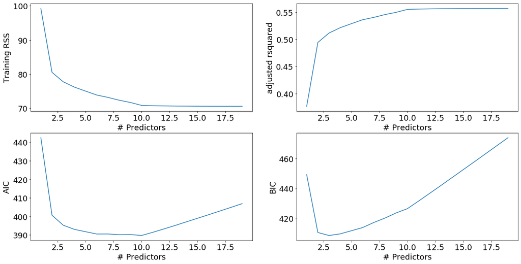

```python
plt.figure(figsize=(20,10))
plt.rcParams.update({'font.size': 18, 'lines.markersize': 10})

# Set up a 2x2 grid so we can look at 4 plots at once
plt.subplot(2, 2, 1)
plt.plot(models["RSS"])
plt.xlabel('# Predictors')
plt.ylabel('Training RSS')

rsquared = models.apply(lambda row: row[1].rsquared, axis=1)
plt.subplot(2, 2, 2)
plt.plot(rsquared)
plt.xlabel('# Predictors')
plt.ylabel('adjusted rsquared')

aic = models.apply(lambda row: row[1].aic, axis=1)
plt.subplot(2, 2, 3)
plt.plot(aic)
plt.xlabel('# Predictors')
plt.ylabel('AIC')

bic = models.apply(lambda row: row[1].bic, axis=1)
plt.subplot(2, 2, 4)
plt.plot(bic)
plt.xlabel('# Predictors')
plt.ylabel('BIC')

plt.show()
```

AIC and BIC are both measures of model selection fit. Training RSS decreases as we add predictors, adjusted $R^2$ tapers after 10 predictors, AIC is minimized at 10 predictors, and BIC is minimized with 3 predictors. There is evidence that 10 predictors is optimal, but we **must** check the test RSS as well.

```python
RSS_test = []
for n in range(1,len(models)):
    feature_set = models.loc[n, "model"].params.index
    y_pred = models.loc[n, "model"].predict(
                    X_test[list(feature_set)])
    RSS_test.append(sum((y_test-y_pred)**2))
```

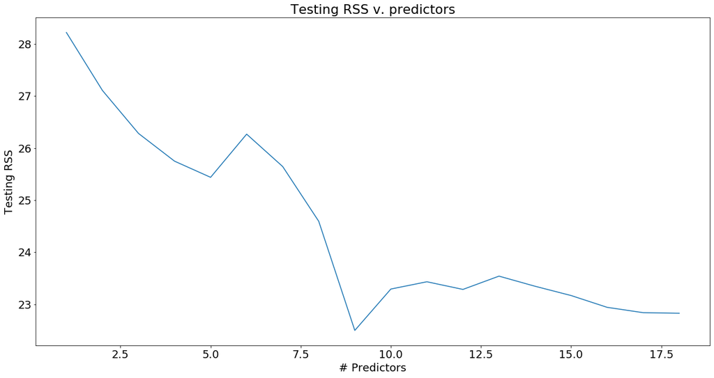

```python
plt.figure(figsize=(20,10))
plt.plot(range(1,len(models)),RSS_test)
plt.xlabel('# Predictors')
plt.ylabel('Testing RSS')
plt.title('Testing RSS v. predictors')
plt.show()
```

```python
print(RSS_test)
```

[output not shown]

The testing RSS graph above shows that even though the training model metrics indicate that a model with 3 predictors (BIC) or a model with 10 predictors (adjusted $R^2$), the best model is actually the best subset model with 9 predictors, when using a 80/20 train/test split. While implementing KFold cross validation would certainly give more accurate results, doing so would further increase run-time and require extensive computing resources.

While best subset selection is a simple and conceptually appealing approach, it suffers from computational limitations. The number of possible models that must be considered grows rapidly as $p$ increases. In general, there are $2^p$ models that involve subsets of p predictors. If $p = 10$, then there are approximately 1,000 possible models to be considered, and if $p = 20$, then there are over one million possibilities! Consequently, best subset selection becomes computationally infeasible for values of $p$ greater than around 40, even with extremely fast modern computers. There are computational shortcuts, so called branch-and-bound techniques, for eliminating some choices, but these have their limitations as $p$ gets large. They also only work for least squares linear regression. We present computationally efficient alternatives to best subset selection next.

## Stepwise Selection

### Forward Selection

Forward stepwise selection is a computationally efficient alternative to best subset selection. While the best subset selection procedure considers all $2^p$ possible models containing subsets of the $p$ predictors, forward step- wise considers a much smaller set of models. Forward stepwise selection begins with a model containing no predictors, and then adds predictors to the model, one-at-a-time, until all of the predictors are in the model. In particular, at each step the variable that gives the greatest additional improvement to the fit is added to the model.

```python
def forward(predictors):
    # Pull out predictors we still need to process
    remaining_predictors= [p for p in X_train.columns if p not in predictors]

    tic = time.time()

    results = []

    for p in remaining_predictors:
        results.append(processSubset(predictors + [p]))

    # Wrap everything up in a nice dataframe
    models = pd.DataFrame(results)

    # Choose the model with the smallest RSS
    best_model = models.loc[models['RSS'].argmin()]

    toc = time.time()
    print ('Processed ', models.shape[0], ' models on ', len(predictors) + 1,
          ' predictors in ', (toc - tic), ' seconds.')

    # Return the best model, along with some other useful information about the model
    return best_model
```

```python
models2 = pd.DataFrame(columns=["RSS", "model"])

tic = time.time()
predictors = []

for i in range(1,len(X_train.columns)+1):
    models2.loc[i] = forward(predictors)
    predictors = models2.loc[i]["model"].model.exog_names[1:]

toc = time.time()
print("Total elapsed time:", (toc-tic), "seconds.")
```

```
Processed  19  models on  1  predictors in  0.0967411994934082  seconds.
Processed  18  models on  2  predictors in  0.10571861267089844  seconds.
Processed  17  models on  3  predictors in  0.10050392150878906  seconds.
Processed  16  models on  4  predictors in  0.09372997283935547  seconds.
Processed  15  models on  5  predictors in  0.09372925758361816  seconds.
Processed  14  models on  6  predictors in  0.09372544288635254  seconds.
Processed  13  models on  7  predictors in  0.09372973442077637  seconds.
Processed  12  models on  8  predictors in  0.10934805870056152  seconds.
Processed  11  models on  9  predictors in  0.07811093330383301  seconds.
Processed  10  models on  10  predictors in  0.07755875587463379  seconds.
Processed  9  models on  11  predictors in  0.06283044815063477  seconds.
Processed  8  models on  12  predictors in  0.05685138702392578  seconds.
Processed  7  models on  13  predictors in  0.05684995651245117  seconds.
Processed  6  models on  14  predictors in  0.053856611251831055  seconds.
Processed  5  models on  15  predictors in  0.04686570167541504  seconds.
Processed  4  models on  16  predictors in  0.04686284065246582  seconds.
Processed  3  models on  17  predictors in  0.04686403274536133  seconds.
Processed  2  models on  18  predictors in  0.015622138977050781  seconds.
Processed  1  models on  19  predictors in  0.015620708465576172  seconds.
Total elapsed time: 1.4084091186523438 seconds.
```

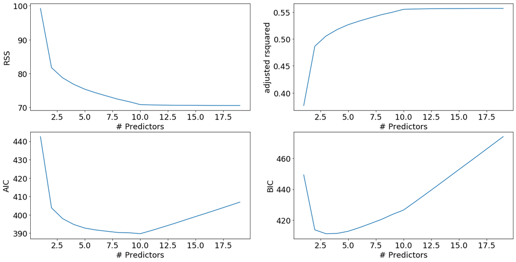

```python
plt.figure(figsize=(20,10))
plt.rcParams.update({'font.size': 18, 'lines.markersize': 10})

# Set up a 2x2 grid so we can look at 4 plots at once
plt.subplot(2, 2, 1)
plt.plot(models2["RSS"])
plt.xlabel('# Predictors')
plt.ylabel('RSS')

rsquared = models2.apply(lambda row: row[1].rsquared, axis=1)
plt.subplot(2, 2, 2)
plt.plot(rsquared)
plt.xlabel('# Predictors')
plt.ylabel('adjusted rsquared')


aic = models2.apply(lambda row: row[1].aic, axis=1)
plt.subplot(2, 2, 3)
plt.plot(aic)
plt.xlabel('# Predictors')
plt.ylabel('AIC')

bic = models2.apply(lambda row: row[1].bic, axis=1)
plt.subplot(2, 2, 4)
plt.plot(bic)
plt.xlabel('# Predictors')
plt.ylabel('BIC')

plt.show()
```

```python
RSS_test_forward = []
for n in range(1,len(models2)):
    feature_set2 = models2.loc[n, "model"].params.index
    y_pred2 = models2.loc[n, "model"].predict(
                    X_test[list(feature_set2)])
    RSS_test_forward.append(sum((y_test-y_pred2)**2))
```

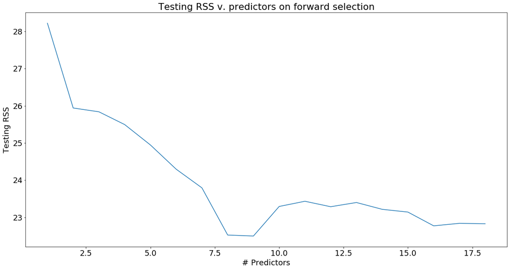

```python
plt.figure(figsize=(20,10))
plt.plot(range(1,len(models2),1),RSS_test_forward)
plt.xlabel('# Predictors')
plt.ylabel('Testing RSS')
plt.title('Testing RSS v. predictors on forward selection')
plt.show()
```

Forward selection is much faster. Looking only at training data measures, it seems that using 10 predictors yields the best model, while looking at testing data reveals only 9 is necessary.

### Backward Selection

Like forward stepwise selection, backward stepwise selection provides an efficient alternative to best subset selection. However, unlike forward stepwise selection, it begins with the full least squares model containing all $p$ predictors, and then iteratively removes the least useful predictor, one-at-a-time.

```python
def backward(predictors):

    tic = time.time()

    results = []

    for combo in itertools.combinations(predictors, len(predictors) - 1):
        results.append(processSubset(combo))

    # Wrap everything up in a nice dataframe
    models = pd.DataFrame(results)

    # Choose the model with the smallest RSS
    best_model = models.loc[models['RSS'].argmin()]

    toc = time.time()
    print ("Processed ", models.shape[0], " models on ",
          len(predictors) - 1, " predictors in ",
          (toc - tic), " seconds.")

    # Return the best model, along with some other useful information about the model
    return best_model
```

```python
models3 = pd.DataFrame(columns=["RSS", "model"], index = range(1,len(X_train.columns)))
tic = time.time()
predictors = X_train.columns

while(len(predictors) > 1):
    models3.loc[len(predictors)-1] = backward(predictors)
    predictors = models3.loc[len(predictors)-1]["model"].model.exog_names[1:]

toc = time.time()
print("Total elapsed time:", (toc-tic), "seconds.")
```

```
Processed  19  models on  18  predictors in  0.1038055419921875  seconds.
Processed  18  models on  17  predictors in  0.09372925758361816  seconds.
Processed  17  models on  16  predictors in  0.09372687339782715  seconds.
Processed  16  models on  15  predictors in  0.10983753204345703  seconds.
Processed  15  models on  14  predictors in  0.06482553482055664  seconds.
Processed  14  models on  13  predictors in  0.06332230567932129  seconds.
Processed  13  models on  12  predictors in  0.04686689376831055  seconds.
Processed  12  models on  11  predictors in  0.0468595027923584  seconds.
Processed  11  models on  10  predictors in  0.09510970115661621  seconds.
Processed  10  models on  9  predictors in  0.05285787582397461  seconds.
Processed  9  models on  8  predictors in  0.05285954475402832  seconds.
Processed  8  models on  7  predictors in  0.0388951301574707  seconds.
Processed  7  models on  6  predictors in  0.0329127311706543  seconds.
Processed  6  models on  5  predictors in  0.027924299240112305  seconds.
Processed  5  models on  4  predictors in  0.025931835174560547  seconds.
Processed  4  models on  3  predictors in  0.02593064308166504  seconds.
Processed  3  models on  2  predictors in  0.015622138977050781  seconds.
Processed  2  models on  1  predictors in  0.03124213218688965  seconds.
Total elapsed time: 1.0609092712402344 seconds.
```

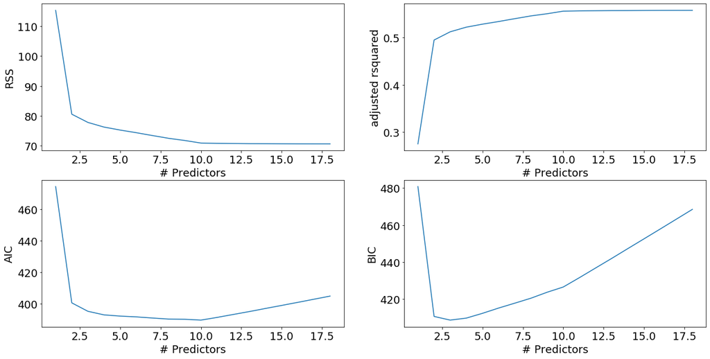

```python
plt.figure(figsize=(20,10))
plt.rcParams.update({'font.size': 18, 'lines.markersize': 10})

# Set up a 2x2 grid so we can look at 4 plots at once
plt.subplot(2, 2, 1)
plt.plot(models3["RSS"])
plt.xlabel('# Predictors')
plt.ylabel('RSS')

rsquared = models3.apply(lambda row: row[1].rsquared, axis=1)
plt.subplot(2, 2, 2)
plt.plot(rsquared)
plt.xlabel('# Predictors')
plt.ylabel('adjusted rsquared')


aic = models3.apply(lambda row: row[1].aic, axis=1)
plt.subplot(2, 2, 3)
plt.plot(aic)
plt.xlabel('# Predictors')
plt.ylabel('AIC')

bic = models3.apply(lambda row: row[1].bic, axis=1)
plt.subplot(2, 2, 4)
plt.plot(bic)
plt.xlabel('# Predictors')
plt.ylabel('BIC')

plt.show()
```

```python
RSS_test_backward = []
for n in range(1,len(models3)):
    feature_set3 = models3.loc[n, "model"].params.index
    y_pred3 = models3.loc[n, "model"].predict(
                    X_test[list(feature_set3)])
    RSS_test_backward.append(sum((y_test-y_pred3)**2))
```

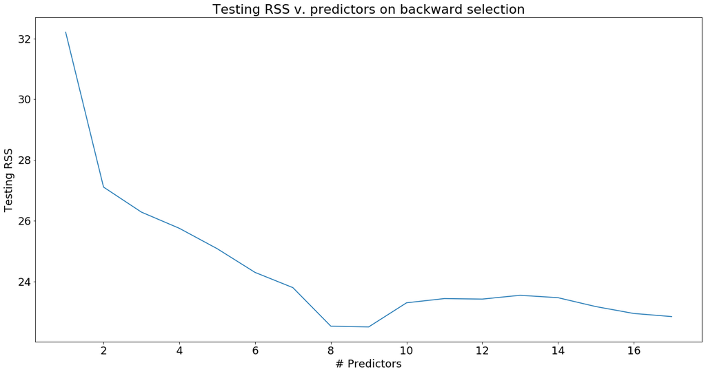

```python
plt.figure(figsize=(20,10))
plt.plot(range(1,len(models3),1),RSS_test_backward)
plt.xlabel('# Predictors')
plt.ylabel('Testing RSS')
plt.title('Testing RSS v. predictors on backward selection')
plt.show()
```

Like forward selection, backward selection is much faster. Looking only at training data measures, it seems that using 10 predictors yields the best model, while looking at testing data reveals only 8 or 9 is necessary.

```python
print("BEST SELECTION")
print (models.loc[5, "model"].params)
print("---------------")
print (models.loc[6, "model"].params)
print("---------------")
print (models.loc[7, "model"].params)
```

```
BEST SELECTION
const         4.487355
Hits          0.006292
Walks         0.005918
Years         0.061801
CRBI          0.000500
Division_W   -0.176227
dtype: float64
---------------
const         4.328702
Hits          0.006911
Walks         0.005528
Years         0.074087
CHmRun        0.001486
League_N      0.164834
Division_W   -0.178242
dtype: float64
---------------
const         4.325047
Hits          0.006533
Walks         0.005129
Years         0.074701
CHmRun        0.001414
PutOuts       0.000220
League_N      0.152401
Division_W   -0.173247
dtype: float64
```

```python
print("FORWARD SELECTION")
print (models2.loc[5, "model"].params)
print("---------------")
print (models2.loc[6, "model"].params)
print("---------------")
print (models2.loc[7, "model"].params)
print("---------------")
print (models2.loc[8, "model"].params)
```

```
FORWARD SELECTION
const         4.466353
CRuns         0.000440
Hits          0.006365
Years         0.064513
Walks         0.005814
Division_W   -0.166895
dtype: float64
---------------
const         4.463299
CRuns         0.000462
Hits          0.005878
Years         0.062994
Walks         0.005209
Division_W   -0.160907
PutOuts       0.000273
dtype: float64
---------------
const         4.462533
CRuns         0.001026
Hits          0.004580
Years         0.068256
Walks         0.008450
Division_W   -0.169300
PutOuts       0.000269
CWalks       -0.000887
dtype: float64
---------------
const         4.578442
CRuns         0.001118
Hits          0.009876
Years         0.066183
Walks         0.009736
Division_W   -0.157155
PutOuts       0.000293
CWalks       -0.000986
AtBat        -0.001854
dtype: float64
```

```python
print("BACKWARD SELECTION")
print(models3.loc[8, "model"].params)
print("---------------")
print(models3.loc[7, "model"].params)
```

```
BACKWARD SELECTION
const         4.578442
AtBat        -0.001854
Hits          0.009876
Walks         0.009736
Years         0.066183
CRuns         0.001118
CWalks       -0.000986
PutOuts       0.000293
Division_W   -0.157155
dtype: float64
---------------
const         4.462533
Hits          0.004580
Walks         0.008450
Years         0.068256
CRuns         0.001026
CWalks       -0.000887
PutOuts       0.000269
Division_W   -0.169300
dtype: float64
```

## Regularization

### Ridge Regression

Ridge regression minimizes $RSS + \lambda \sum\beta^2$, where $ \lambda$ (here denoted $\alpha$ to match the module's naming convention) is a tuning parameter. The second term is called a shrinkage penalty and it is small when betas are close to zero so it has an effect of shrinking them (but not setting them) to zero. The tuning parameter $\lambda$ serves to control the relative impact of these two terms on the regression coefficient estimates. When $\lambda$ = 0, the penalty term has no effect, and ridge regression will produce the least squares estimates. However, as $\lambda \rightarrow \infty$, the impact of the shrinkage penalty grows, and the ridge regression coefficient estimates will approach zero. Unlike least squares, which generates only one set of co-efficient estimates, ridge regression will produce a different set of coefficient estimates for each value of $\lambda$. Selecting a good value for $\lambda$ is critical. We will generate an array of $\lambda$'s covering the full range.

```python
#resplit the data since we altered X previously, don't use log transform

df = pd.read_csv('Hitters.csv')
df = df.dropna().drop('Name', axis=1)

# get_dummies convert categorical variables into indicator variables.
dummies = pd.get_dummies(df[['League', 'Division', 'NewLeague']]) #One Hot encding
y = df.Salary

# Drop the column with independent variables and categorical variables
X_ = df.drop(['Salary', 'League', 'Division', 'NewLeague'], axis=1).astype('float64')
X = pd.concat([X_, dummies[['League_N', 'Division_W', 'NewLeague_N']]], axis=1)

X_train, X_test , y_train, y_test = train_test_split(X, y, test_size=0.5, random_state=1)
```

```python
alphas = 10**np.linspace(10, -2, 100) * 0.5
alphas
```

```
array([5.00000000e+09, 3.78231664e+09, 2.86118383e+09, 2.16438064e+09,
       1.63727458e+09, 1.23853818e+09, 9.36908711e+08, 7.08737081e+08,
       5.36133611e+08, 4.05565415e+08, 3.06795364e+08, 2.32079442e+08,
       1.75559587e+08, 1.32804389e+08, 1.00461650e+08, 7.59955541e+07,
       5.74878498e+07, 4.34874501e+07, 3.28966612e+07, 2.48851178e+07,
       1.88246790e+07, 1.42401793e+07, 1.07721735e+07, 8.14875417e+06,
       6.16423370e+06, 4.66301673e+06, 3.52740116e+06, 2.66834962e+06,
       2.01850863e+06, 1.52692775e+06, 1.15506485e+06, 8.73764200e+05,
       6.60970574e+05, 5.00000000e+05, 3.78231664e+05, 2.86118383e+05,
       2.16438064e+05, 1.63727458e+05, 1.23853818e+05, 9.36908711e+04,
       7.08737081e+04, 5.36133611e+04, 4.05565415e+04, 3.06795364e+04,
       2.32079442e+04, 1.75559587e+04, 1.32804389e+04, 1.00461650e+04,
       7.59955541e+03, 5.74878498e+03, 4.34874501e+03, 3.28966612e+03,
       2.48851178e+03, 1.88246790e+03, 1.42401793e+03, 1.07721735e+03,
       8.14875417e+02, 6.16423370e+02, 4.66301673e+02, 3.52740116e+02,
       2.66834962e+02, 2.01850863e+02, 1.52692775e+02, 1.15506485e+02,
       8.73764200e+01, 6.60970574e+01, 5.00000000e+01, 3.78231664e+01,
       2.86118383e+01, 2.16438064e+01, 1.63727458e+01, 1.23853818e+01,
       9.36908711e+00, 7.08737081e+00, 5.36133611e+00, 4.05565415e+00,
       3.06795364e+00, 2.32079442e+00, 1.75559587e+00, 1.32804389e+00,
       1.00461650e+00, 7.59955541e-01, 5.74878498e-01, 4.34874501e-01,
       3.28966612e-01, 2.48851178e-01, 1.88246790e-01, 1.42401793e-01,
       1.07721735e-01, 8.14875417e-02, 6.16423370e-02, 4.66301673e-02,
       3.52740116e-02, 2.66834962e-02, 2.01850863e-02, 1.52692775e-02,
       1.15506485e-02, 8.73764200e-03, 6.60970574e-03, 5.00000000e-03])
```

```python
ridge = Ridge(normalize=True)
coeffs = []

for a in alphas:
    ridge.set_params(alpha=a)
    ridge.fit(X, y)
    coeffs.append(ridge.coef_)

np.shape(coeffs)
```

```
(100, 19)
```

We expect the coeffcient estimates to be much smaller, in terms of L2 norm, when a large value of alpha is used, as compared to when a small value of alpha is used. Let's plot find out:

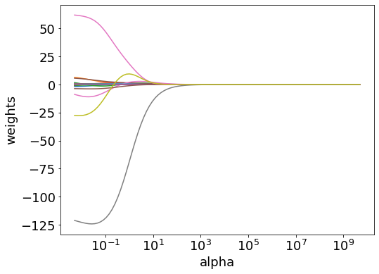

```python
plt.figure(figsize=(8,6))
ax = plt.gca()
ax.plot(alphas, coeffs)
ax.set_xscale('log')
plt.axis('tight')
plt.xlabel('alpha')
plt.ylabel('weights')
plt.show()
```

```python
ridge2 = Ridge(alpha=4, normalize=True)
ridge2.fit(X_train, y_train)
pred2 = ridge2.predict(X_test)
print (pd.Series(ridge2.coef_, index=X.columns))
print (mean_squared_error(y_test, pred2))
```

```
AtBat           0.098658
Hits            0.446094
HmRun           1.412107
Runs            0.660773
RBI             0.843403
Walks           1.008473
Years           2.779882
CAtBat          0.008244
CHits           0.034149
CHmRun          0.268634
CRuns           0.070407
CRBI            0.070060
CWalks          0.082795
PutOuts         0.104747
Assists        -0.003739
Errors          0.268363
League_N        4.241051
Division_W    -30.768885
NewLeague_N     4.123474
dtype: float64
106216.52238005563
```

```python
# Use the cross-validation package to split data into training and test sets
X_train, X_test , y_train, y_test = train_test_split(X, y, test_size=0.5, random_state=1)

ridge3 = Ridge(alpha=10**10, normalize=True)
ridge3.fit(X_train, y_train)
pred3 = ridge3.predict(X_test)
print (pd.Series(ridge3.coef_, index=X.columns))
print (mean_squared_error(y_test, pred3))
```

```
AtBat          1.317464e-10
Hits           4.647486e-10
HmRun          2.079865e-09
Runs           7.726175e-10
RBI            9.390640e-10
Walks          9.769219e-10
Years          3.961442e-09
CAtBat         1.060533e-11
CHits          3.993605e-11
CHmRun         2.959428e-10
CRuns          8.245247e-11
CRBI           7.795451e-11
CWalks         9.894387e-11
PutOuts        7.268991e-11
Assists       -2.615885e-12
Errors         2.084514e-10
League_N      -2.501281e-09
Division_W    -1.549951e-08
NewLeague_N   -2.023196e-09
dtype: float64
172862.23580379886
```

This big penalty shrinks the coefficients to a very large degree, essentially reducing to a model containing just the intercept. This over-shrinking makes the model more biased, resulting in a higher MSE. We now want to check if there is any benefit to performing ridge regression instead of just performing least squares regression. Least square regression is simply ridge regression with a zero alpha.

```python
ridge4 = Ridge(alpha=0, normalize=True)
ridge4.fit(X_train, y_train)
pred = ridge4.predict(X_test)
print (pd.Series(ridge4.coef_, index=X.columns))
```

```
AtBat           -1.821115
Hits             4.259156
HmRun           -4.773401
Runs            -0.038760
RBI              3.984578
Walks            3.470126
Years            9.498236
CAtBat          -0.605129
CHits            2.174979
CHmRun           2.979306
CRuns            0.266356
CRBI            -0.598456
CWalks           0.171383
PutOuts          0.421063
Assists          0.464379
Errors          -6.024576
League_N       133.743163
Division_W    -113.743875
NewLeague_N    -81.927763
dtype: float64
```

```python
mean_squared_error(y_test, pred)
```

```
116690.46856660438
```

```python
# check neg_mean_squared_error
ridgecv = RidgeCV(alphas=alphas, scoring='neg_mean_squared_error', normalize=True)
ridgecv.fit(X_train, y_train)
ridgecv.alpha_ #find the best alpha
```

```
0.5748784976988678
```

```python
ridge5 = Ridge(alpha=ridgecv.alpha_, normalize=True)
ridge5.fit(X_train, y_train)
mean_squared_error(y_test, ridge5.predict(X_test))
```

```
99825.6489629273
```

```python
ridge5.fit(X, y)
pd.Series(ridge5.coef_, index=X.columns)
```

```
AtBat           0.055838
Hits            0.934879
HmRun           0.369048
Runs            1.092480
RBI             0.878259
Walks           1.717770
Years           0.783515
CAtBat          0.011318
CHits           0.061101
CHmRun          0.428333
CRuns           0.121418
CRBI            0.129351
CWalks          0.041990
PutOuts         0.179957
Assists         0.035737
Errors         -1.597699
League_N       24.774519
Division_W    -85.948661
NewLeague_N     8.336918
dtype: float64
```

As expected, none of the coefficients are exactly zero. Ridge regression does not perform variable selection. Ridge regression’s advantage over least squares is rooted in the bias-variance trade-off. As $\lambda$ increases, the flexibility of the ridge regression fit decreases, leading to decreased variance but increased bias.

### Lasso Regression

We saw that ridge regression with a wise choice of $\lambda$ (called $\alpha$) can outperform least squares as well as the null model on the Hitters data set. We now ask whether the lasso can yield either a more accurate or a more interpretable model than ridge regression. Lasso minimizes $RSS + \lambda\sum|\beta|$. As with ridge regression, the lasso shrinks the coefficient estimates towards zero. However, in the case of the lasso, the L1 penalty has the effect of forcing some of the coefficient estimates to be exactly equal to zero when the tuning parameter $\lambda$ is sufficiently large. In order to fit a lasso model, we'll use the Lasso function; however, this time we'll need to include the argument max_iter=10000. Other than that change, we proceed just as we did in fitting a ridge model.

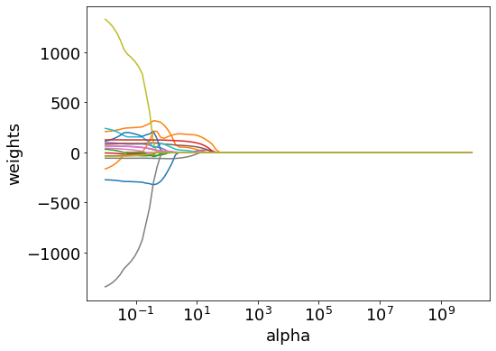

```python
plt.figure(figsize=(8,6))
lasso = Lasso(max_iter=10000, normalize=True)
coeffs = []

for a in alphas:
    lasso.set_params(alpha = a)
    lasso.fit(scale(X_train), y_train)
    coeffs.append(lasso.coef_)

ax = plt.gca()
ax.plot(alphas * 2, coeffs)
ax.set_xscale('log')
plt.axis('tight')
plt.xlabel('alpha')
plt.ylabel('weights')

plt.show()
```

```python
lassocv = LassoCV(alphas=None, cv=10, max_iter=100000, normalize=True)
lassocv.fit(X_train, y_train)

lasso.set_params(alpha=lassocv.alpha_)
lasso.fit(X_train, y_train)
mean_squared_error(y_test, lasso.predict(X_test))
```

```
104960.65853895503
```

This is substantially lower than the test set MSE of the null model and of least squares, and only a little worse than the test MSE of ridge regression with alpha chosen by cross－validation. However, the lasso has a substantial advantage over ridge regression in that the resulting coefficient estimates are sparse. Here we see that 13 of the 19 coefficient estimates are exactly zero.

```python
pd.Series(lasso.coef_, index=X.columns)
```

```
AtBat           0.000000
Hits            1.082446
HmRun           0.000000
Runs            0.000000
RBI             0.000000
Walks           2.906388
Years           0.000000
CAtBat          0.000000
CHits           0.000000
CHmRun          0.219367
CRuns           0.000000
CRBI            0.513975
CWalks          0.000000
PutOuts         0.368401
Assists        -0.000000
Errors         -0.000000
League_N        0.000000
Division_W    -89.064338
NewLeague_N     0.000000
dtype: float64
```

## Additional Information

AIC and BIC both models that help us decide which model to select.

The Akaike information criterion (AIC) is an estimator of out-of-sample prediction error and thereby relative quality of statistical models for a given set of data.

The Bayesian information criterion (BIC) is a criterion for model selection among a finite set of models. It is based, in part, on the likelihood function, and it is closely related to Akaike information criterion (AIC) but with a penalty term for the number of parameters in the model.

#### AIC

The AIC criterion is defined for a large class of models fit by maximum likelihood. In the case of the model with Gaussian errors, maximum likelihood and least squares are the same thing. $\sigma^2$ is an estimate of the variance of the error ε associated with each response measurement adds a penalty of $2dσ^2$ to the training RSS in order to adjust for the fact that the training error tends to underestimate the test error. Clearly, the penalty increases as the number of predictors in the model increases; this is intended to adjust for the corresponding decrease in training RSS.